# Probability distributions of key quantities in two-state discrete-time Markov chain

Luiz Max Carvalho

2021-04-12

## Introduction

In this document we will illustrate some of the functionality of **BinaryMarkovChains** package and verify the probability distribution of key quantities in a two-state discrete-time Markov chain (DTMC), such as the recurrence and occupation times, and the (maximum) number of state transitions.

We are interested in computing a few key probabilistic quantities for a DTMC $(X_k)_{k\geq 0}$ with state-space ${\cal S} = \{0, 1\}$ and matrix of transition probabilities
$$\boldsymbol{P}_x :=
\begin{bmatrix}
1-\alpha & \alpha \\
\beta & 1-\beta
\end{bmatrix}$$
for $\alpha, \beta \in [0, 1]^2$. The marginal success probability is $p := \operatorname{Pr}(X_k = 1) = \alpha/(\alpha + \beta)$.

Our approach here will be to simulate a large number of replicates (`nsims`) of a DTMC with `N` observations. We will then compare results from these simulations with their theoretical counterparts, implemented in **BinaryMarkovChains**.

First, let’s set up.

```r
library(BinaryMarkovChains)
library(markovchain)

set.seed(666)
p <- 0.666 ## marginal success probability
( maxAlpha <- get_max_alpha(p) ) ## maximum value for alpha given p
```

```
#> [1] 1
```

```r
indep_sampling <- FALSE

if(indep_sampling){
  alpha <- p
}else{
  alpha <- runif(1, 0, maxAlpha)
}
beta <- exp(log(alpha)  + log1p(-p) - log(p))

transition.matrix <- abs(matrix(c(1-alpha, alpha, beta, 1-beta),
                                ncol = 2, nrow = 2, byrow = TRUE))
MC.binary <- new("markovchain",
                 states = c("0", "1"),
                 transitionMatrix = transition.matrix,
                 name = "Binary")

nsims <- 10000 ## number of Monte Carlo simulations
N <- 1000 ## Markov chain iterations

simulate_once <- function(i){
  temp <- markovchainSequence(n = N, markovchain = MC.binary, t0 = "0")
  recurrence.time <- min(which(temp[-1] == "0"))
  X <- as.numeric(temp)
  Y <- form_Y(X)
  return(list(X = X, # Markov states
              Y = Y, # Transitions
              T = recurrence.time, # time to (first) return to "0"
              occ_X = sum(X),
              occ_Y = sum(Y))
  )
}
```

Now run the simulation.

```r
simu.time <- system.time(
  ## please increase the number of cores to a modern standard
  raw.simus <- parallel::mclapply(1:nsims, simulate_once, mc.cores = 2)
)
simu.time
```

```
#>    user  system elapsed
#>   3.483   0.354   3.836
```

Finally, let’s take a look at a few quantities.

### Recurrence time

Assuming $X_0 = 0$ we want to know the distribution of the time to return to $0$, i.e., the random variable $T = \inf\,\{n \geq 1 : X_n = 0 \}$. We know $T$ follows a geometric distribution (Cox & Miller, 1965, page 83) and that $E[T] = (\alpha+\beta)/\beta$:

```r
Ts <- unlist(lapply(raw.simus, function(x) x$T))
mean(Ts)
```

```
#> [1] 2.6337
```

```r
(alpha + beta)/beta
```

```
#> [1] 2.994012
```

Now let’s visualise the probability mass function (p.m.f) of $T$, implemented in `recurrence_time_pmf()`:

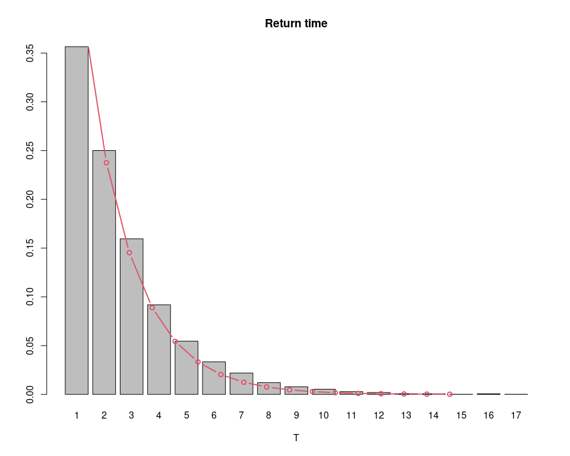

```r
rtime.tab <- table(Ts)
barplot(rtime.tab/nsims, xlab = expression(T), main = "Return time")
rtimes <- as.numeric(names(rtime.tab))
rprobs <- recurrence_time_pmf(x = rtimes, alpha = alpha, beta = beta)
points(rtimes, rprobs/sum(rprobs), type = "b", lwd = 2, col = 2)
```

Seems spot on. Now, let’s look at the occupation time for the chain, $W_M := \sum_{k=0}^M X_k$.

```r
Ws <- unlist(lapply(raw.simus, function(x) x$occ_X))
summary(Ws)
```

```
#>    Min. 1st Qu.  Median    Mean 3rd Qu.    Max.
#>     614     658     666     666     675     713
```

```r
mean(Ws)
```

```
#> [1] 666.0202
```

```r
var(Ws)
```

```
#> [1] 160.6353
```

We know the p.m.f. for $W_M$ from Theorem 1 in [Bhattacharya & Gupta (1980)](https://www.sciencedirect.com/science/article/pii/0166218X8090044X), with a minor typo fixed. This is implemented in `occupation_time_pmf()`. Let’s see it in action:

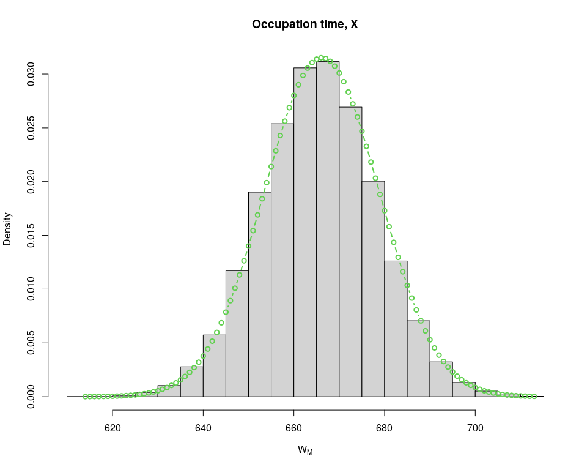

```r
occXs <- min(Ws):max(Ws)
poccXs <- occupation_time_pmf(x = occXs, n = N, alpha = alpha, beta = beta, X0 = "0")

hist(Ws, probability = TRUE, xlab = expression(W[M]), main = "Occupation time, X")
points(occXs, poccXs/sum(poccXs), type = "b", col = 3, lwd = 2)
```

Another important quantity in our analysis is the number of state transitions $0 \to 1$ and $1 \to 0$, also called *switches*. It turns out we can compute the p.m.f. of the number of switches, $Z_M$, by constructing another two-state DTMC $(Y_j)_{j\geq 0}$ *via* $Y_j := |X_j-X_{j-1}|$ and defining $Y_0 = 0$. This new DTMC has generator

$$\boldsymbol{P}_y :=
\begin{bmatrix}
1-a & a \\
b & 1-b
\end{bmatrix},$$
with
$$\begin{align}
a &= \frac{\alpha\beta \left[ 2 - (\alpha + \beta)\right]}{(1-\beta)\alpha + \beta(1-\alpha)},\\
b &= \frac{\alpha\beta \left[ 2 - (\alpha + \beta)\right]}{2\alpha\beta}.
\end{align}$$
The package has utility functions `get_a()` and `get_b()` to facilitate computing these expressions. The number of state-transitions is thus the occupation time for $(Y_j)_{j\geq 0}$: $Z_M = \sum_{j=0} Y_j$. Let’s confirm. First, a look at the statistical summaries of the distribution of $Z_M$:

```r
Zs <- unlist(lapply(raw.simus, function(x) x$occ_Y))
summary(Zs)
```

```
#>    Min. 1st Qu.  Median    Mean 3rd Qu.    Max.
#>   456.0   505.0   516.0   516.6   528.0   582.0
```

A now we visualise the p.m.f.,

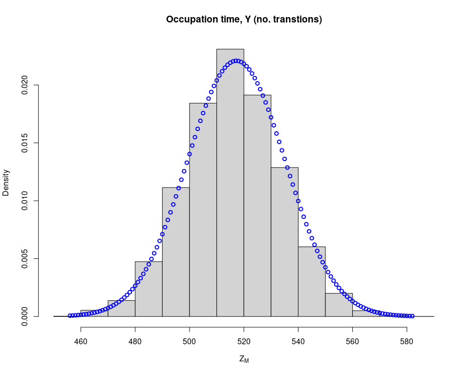

```r
a <- get_a(alpha = alpha, beta = beta)
b <- get_b(alpha = alpha, beta = beta)

occYs <- min(Zs):max(Zs)
poccYs <- occupation_time_pmf(x = occYs, n = N, alpha = a, beta = b, X0 = "0")

hist(Zs, probability = TRUE, xlab = expression(Z[M]), main = "Occupation time, Y (no. transtions)")
points(occYs, poccYs/sum(poccYs), type = "b", col = "blue", lwd = 2)
```

Finally, we are prepared to look at the distribution of the maximum number of state-transitions given a certain occupation time, $\Delta_{\max}(W_M)$. The function $\Delta_{\max}(\cdot)$ can be computed with `get_maxK()` and the p.m.f. for $\Delta_{\max}(W_M)$ is implemented in `max_transitions_pmf()`.

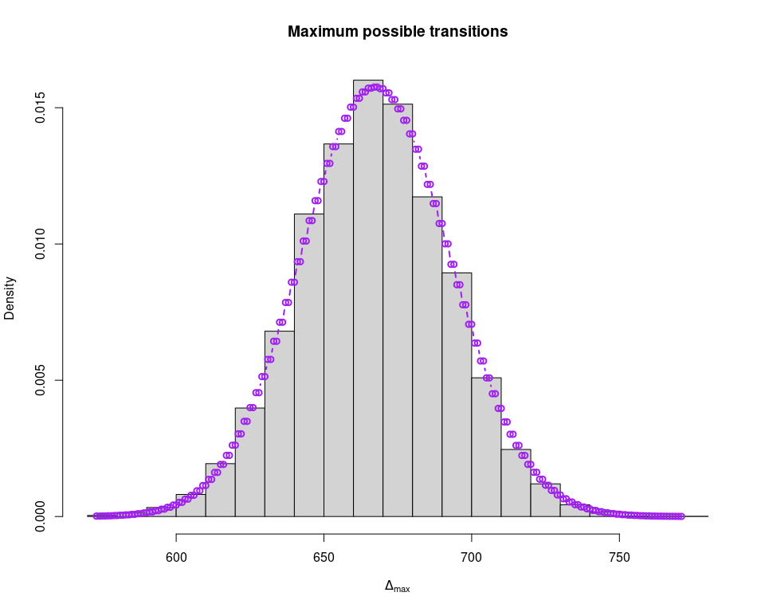

```r
max.transitions <- get_maxK(Sx = Ws, M = N)

Ms <- min(max.transitions):max(max.transitions)
probMs <- max_transitions_pmf(x = Ms, n = N, alpha = alpha, beta = beta)

hist(max.transitions, probability = TRUE,
     xlab = expression(Delta[max]), main = "Maximum possible transitions")
points(Ms, probMs/sum(probMs), type = "b", col = "purple", lwd = 2)
```